# caracteristicas_inmueble

## Campos involucrados

- tipodepropiedad
- antiguedad
- habitaciones
- banos
- metroscubiertos
- metrostotales

## Hipótesis

- En las zonas urbanas debería haber mayor cantidad de apartamentos que cualquier otro tipo de propiedad
- Si consideramos características similares los departamentos deberían ser más caros que las casas
- Las casas tienen más metros cuadrados que los departamentos (en general)
- El factor más importante para el precio de una vivienda son el tipo de propiedad y los metros cuadrados
- Las publicaciones de lugares comerciales deberían estar concentradas en lugares más céntricos

```python
%run "../../utils/dataset_parsing.ipynb"
%run "../../utils/graphs.ipynb"
import seaborn as sns

publicaciones = levantar_datos("../../" + DATASET_RELATIVE_PATH)
```

## Porcentaje de publicaciones de cada tipo de propiedad en cada provincia

Se quiere saber qué es lo que más se publica en cada provincia. Seguramente la mayor cantidad de publicaciones sean de departamentos o casas. En centros urbanos muy poblados, como el distrito federal, seguramente haya mayor cantidad de publicaciones de departamentos, mientras que en zonas no tan urbanizadas la cantidad de publicaciones de casas sean predominantes.

```python
#Se obtiene un dataframe con la cantidad de publicaciones de cada provincia
publicaciones_por_provincia = publicaciones.groupby('provincia').agg({'id':'count'})
```

```python
publicaciones_por_provincia_y_tipo = publicaciones.groupby(['provincia', 'tipodepropiedad']).agg({'id':'count'}).reset_index()
publicaciones_por_provincia_y_tipo = pd.merge(publicaciones_por_provincia_y_tipo, publicaciones_por_provincia, on='provincia')
publicaciones_por_provincia_y_tipo = publicaciones_por_provincia_y_tipo.rename(columns={'id_x':'cantidad_tipo', 'id_y':'cantidad_total'})
publicaciones_por_provincia_y_tipo['porcentaje'] = publicaciones_por_provincia_y_tipo['cantidad_tipo'] / publicaciones_por_provincia_y_tipo['cantidad_total']
publicaciones_por_provincia_y_tipo = publicaciones_por_provincia_y_tipo.set_index(['provincia', 'tipodepropiedad'])
```

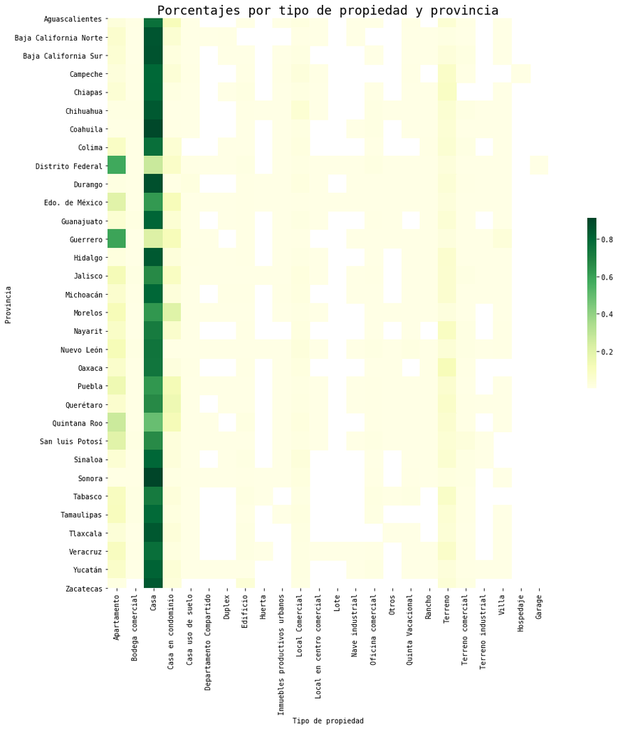

```python
publicaciones_por_provincia_y_tipo_for_heatmap = publicaciones_por_provincia_y_tipo.pivot_table(index='provincia', columns='tipodepropiedad', values='porcentaje', aggfunc='sum')
get_heatmap(publicaciones_por_provincia_y_tipo_for_heatmap, xlabel="Tipo de propiedad", ylabel="Provincia", title="Porcentajes por tipo de propiedad y provincia")
```

#### Se puede visualizar en el heatmap que en general la cantidad de publicaciones de casas es muy grande, en relación con los demás tipos de propiedades.

Efectivamente en el distrito federal la cantidad de departamento es muy alta en comparación con las casas. Lo mismo ocurre en Guerrero.

## Relación entre tipo de propiedad y precio

A continuación intentaremos determinar el impacto que tiene el tipo de propiedad en el precio. Para ello nos concetraremos primero en el grupo de tipos de propiedad correspondiente a las viviendas. Este grupo tendrá los inmuebles de tipo: Apartamento, Casa, Casa en condominio, Casa uso de suelo, Departamento Compartido y Duplex.

```python
# Obtenemos un df con las publicaciones de viviendas
tipo_vivienda = ['Apartamento', 'Casa', 'Casa en condominio', 'Casa uso de suelo', 'Departamento Compartido', 'Duplex']
publicaciones_viviendas = publicaciones.set_index('tipodepropiedad')
publicaciones_viviendas = publicaciones_viviendas.filter(items=tipo_vivienda, axis=0)
publicaciones_viviendas.reset_index(inplace=True)
```

Por ahora tomemos este df tal como está y comparemos los precios utilizando un Boxplot.

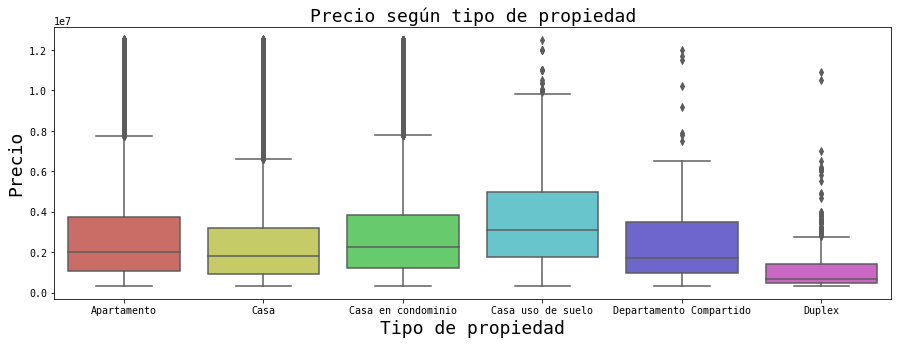

```python
get_boxplot(publicaciones_viviendas, 'tipodepropiedad', 'precio', (15,5), label_x='Tipo de propiedad', label_y='Precio', title='Precio según tipo de propiedad')
```

Tener en cuenta que la escala de precios es 1e7, por lo tanto 0.2 es 2,000,000.00. A simple vista los apartamentos, las casas y las casas en condominio tienen precios similares (en promedio). El problema de este análisis es que no se tiene en cuenta que existen otros factores que podrían variar el precio, por ejemplo los metros cuadrados. Es decir si una casa y un apartamento tienen metros cuadrados similares, ¿El precio también es similar?.

### Relación entre tipo de propiedad, metros cuadrados y precio

Primero verifiquemos que todas las propiedades tienen los valores de metros cuadrados.

```python
publicaciones_viviendas.isnull().sum()
```

```
tipodepropiedad                    0
id                                 0
titulo                          5054
descripcion                     1458
direccion                      47522
ciudad                           330
provincia                        143
antiguedad                     34858
habitaciones                    4760
garages                        31185
banos                          10918
metroscubiertos                 8054
metrostotales                  46972
idzona                         25836
lat                           113502
lng                           113502
fecha                              0
gimnasio                           0
usosmultiples                      0
piscina                            0
escuelascercanas                   0
centroscomercialescercanos         0
precio                             0
mes                                0
ano                                0
dia                                0
precio_metro_cubierto           8054
precio_metro_total             46972
gps                           114068
dtype: int64
```

```python
publicaciones_viviendas.loc[(publicaciones_viviendas['metroscubiertos'].isnull()) & (publicaciones_viviendas['metrostotales'].isnull())]
```

|  | tipodepropiedad | id | titulo | descripcion | direccion | ciudad | provincia | antiguedad | habitaciones | garages | ... | piscina | escuelascercanas | centroscomercialescercanos | precio | mes | ano | dia | precio_metro_cubierto | precio_metro_total | gps |
| --- | --- | --- | --- | --- | --- | --- | --- | --- | --- | --- | --- | --- | --- | --- | --- | --- | --- | --- | --- | --- | --- |

0 rows × 29 columns

Como se observa hay publicaciones que no tienen los metros cuadrados cubiertos o bien no tienen los metros cuadrados totales, pero no hay ninguna que no tenga ninguno de los 2 datos. Esto podría indicar que en caso que los metros totales estén en null, significa que los metros cubiertos son los metros totales y viceversa. Para no dejar fuera del análisis estas publicaciones consideraremos que lo dicho anteriormente es cierto, por lo tanto actualizaremos los valores.

```python
publicaciones_viviendas.loc[publicaciones_viviendas['metroscubiertos'].isnull(), ['metroscubiertos']] = publicaciones_viviendas['metrostotales']
publicaciones_viviendas.loc[publicaciones_viviendas['metrostotales'].isnull(), ['metrostotales']] = publicaciones_viviendas['metroscubiertos']
#Verificamos que no haya valores en 0
publicaciones_viviendas.loc[publicaciones_viviendas['metrostotales'] == 0]
```

|  | tipodepropiedad | id | titulo | descripcion | direccion | ciudad | provincia | antiguedad | habitaciones | garages | ... | piscina | escuelascercanas | centroscomercialescercanos | precio | mes | ano | dia | precio_metro_cubierto | precio_metro_total | gps |
| --- | --- | --- | --- | --- | --- | --- | --- | --- | --- | --- | --- | --- | --- | --- | --- | --- | --- | --- | --- | --- | --- |

0 rows × 29 columns

Ahora que todas las propiedades tienen valores en el campo metros cuadrados es necesario determinar un rango de análisis. Análiamos con un histograma en qué rangos se encuentran aproximadamente la mayor cantidad de publicaciones.

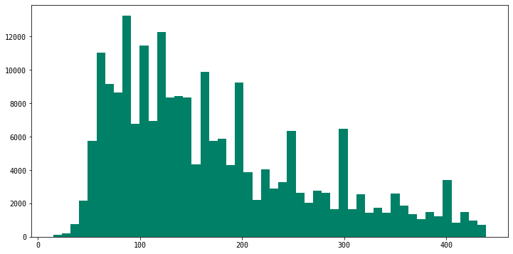

```python
get_hist(publicaciones_viviendas["metrostotales"], bins=50)
```

```python
publicaciones_entre_120_y_130 = publicaciones_viviendas.loc[(publicaciones_viviendas["metrostotales"] >= 120) & (publicaciones_viviendas["metrostotales"] <= 130)]
publicaciones_entre_120_y_130.groupby("tipodepropiedad").agg({"id":"count"})
```

| tipodepropiedad | id |
| --- | --- |
| Apartamento | 3626 |
| Casa | 11245 |
| Casa en condominio | 1442 |
| Casa uso de suelo | 38 |
| Departamento Compartido | 11 |
| Duplex | 16 |

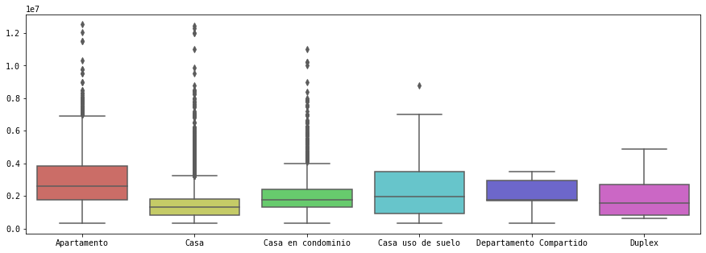

```python
get_boxplot(publicaciones_entre_120_y_130, 'tipodepropiedad', 'precio', (15,5))
```

De este gráfico sólo podemos considerar válidos los datos de departamentos, casas y casas en condominio, dado que la cantidad de muestras de los demás tipos de propiedades no es representativo. Si consideramos propiedades de metros similares vemos que los departamentos son más caros. Entonces por qué en el gráfico anterior mostraba que las casas y los departamentos tienen precios similares y aquí no ocurre eso? Es de suponer que la casas tienen más metros cuadrados que los departamentos en general, por lo tanto si tomamos las propiedades sin limitar las demás características las casas tienden a tener precios similares a los departamentos por la cantidad de metros cuadrados. Lo anterior se puede verificar con el siguiente gráfico.

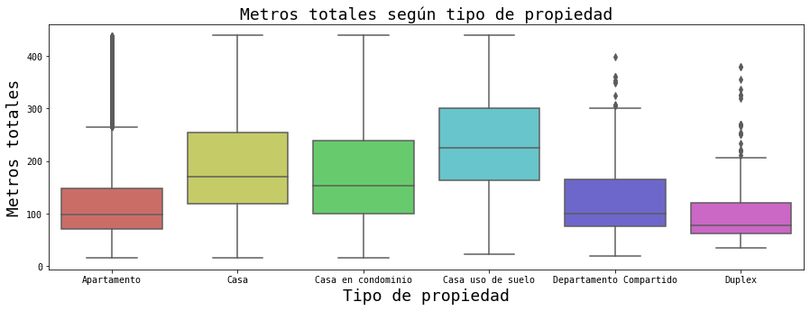

```python
get_boxplot(publicaciones_viviendas, 'tipodepropiedad', 'metrostotales', (15,5), title="Metros totales según tipo de propiedad", label_x="Tipo de propiedad", label_y="Metros totales")
```

En el siguiente gráfico se puede observar el cambio de precio según la cantidad de metros cuadrados, por tipo de propiedad.

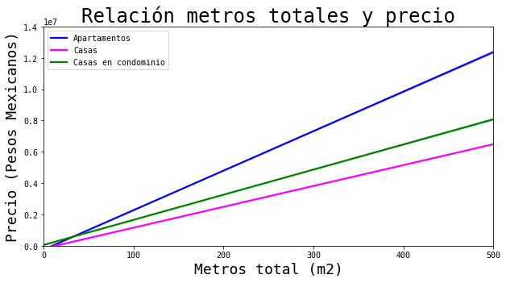

```python
publicaciones_apartamentos = publicaciones_viviendas.loc[publicaciones_viviendas['tipodepropiedad'] == 'Apartamento']
publicaciones_casas = publicaciones_viviendas.loc[publicaciones_viviendas['tipodepropiedad'] == 'Casa']
publicaciones_casas_condominio = publicaciones_viviendas.loc[publicaciones_viviendas['tipodepropiedad'] == 'Casa en condominio']
f, ax = plt.subplots(figsize=(10,5))
ax.set(xlim=(0, 500), ylim=(0, 14000000))
#sns.scatterplot(x='metrostotales', y='precio', data=publicaciones_viviendas.loc[publicaciones_viviendas['tipodepropiedad'] == 'Apartamento'])
sns.regplot(x=publicaciones_apartamentos['metrostotales'],y=publicaciones_apartamentos['precio'],color='blue',scatter=False)
sns.regplot(x=publicaciones_casas['metrostotales'],y=publicaciones_casas['precio'],color='magenta',scatter=False)
sns.regplot(x=publicaciones_casas_condominio['metrostotales'],y=publicaciones_casas_condominio['precio'],color='green',scatter=False)

plt.legend(labels=['Apartamentos','Casas','Casas en condominio'])
plt.title('Relación metros totales y precio', size=24)
plt.xlabel('Metros total (m2)', size=18)
plt.ylabel('Precio (Pesos Mexicanos)', size=18);
```

### Antigüedad

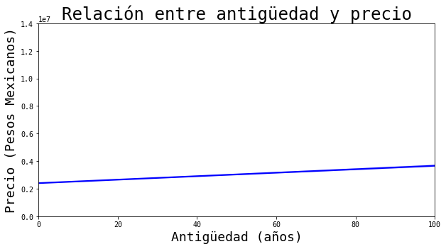

```python
f, ax=plt.subplots(figsize=(10,5))
ax.set(xlim=(0, 100), ylim=(0, 14000000))
sns.regplot(x='antiguedad',y='precio',data=publicaciones_viviendas, color='blue',scatter=False)

plt.title('Relación entre antigüedad y precio', size=24)
plt.xlabel('Antigüedad (años)', size=18)
plt.ylabel('Precio (Pesos Mexicanos)', size=18);
```

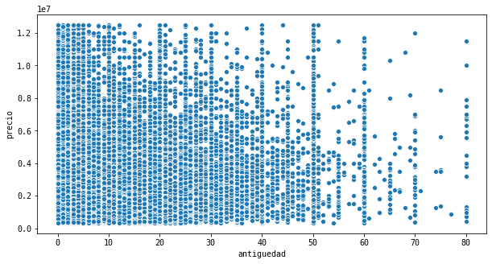

```python
plt.subplots(figsize=(10,5))
sns.scatterplot(x='antiguedad', y='precio', data=publicaciones_viviendas)
```

El aumento de precio a medida que la antigüedad es mayor también puede deberse a que hay mayor cantidad de metros cuadrados en construcciones más antiguas.

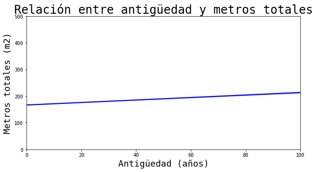

```python
f, ax=plt.subplots(figsize=(10,5))
ax.set(xlim=(0, 100), ylim=(0, 500))
sns.regplot(x='antiguedad',y='metrostotales',data=publicaciones_viviendas, color='blue',scatter=False)

plt.title('Relación entre antigüedad y metros totales', size=24)
plt.xlabel('Antigüedad (años)', size=18)
plt.ylabel('Metros totales (m2)', size=18);
```

### Baños y habitaciones

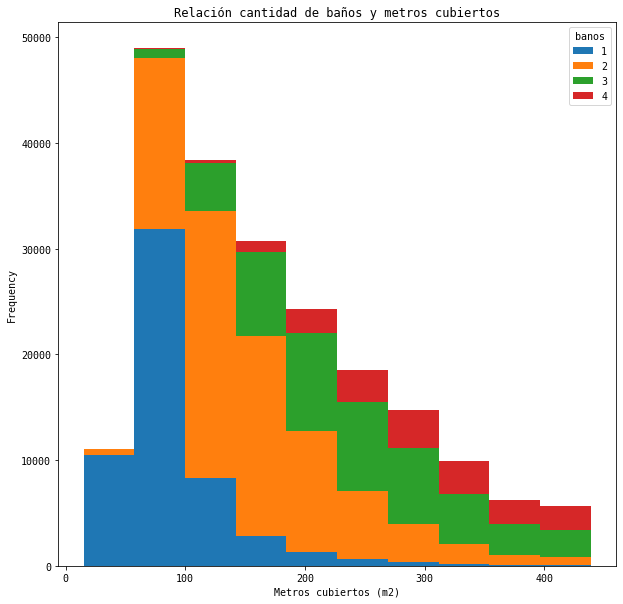

```python
convert_dict={'banos':'int'}
publicaciones_viviendas_con_bano = publicaciones_viviendas.loc[~publicaciones_viviendas['banos'].isnull(), ['banos','metroscubiertos']].astype(convert_dict)
ax = publicaciones_viviendas_con_bano.pivot(columns='banos')['metroscubiertos'].plot(kind = 'hist', stacked=True, figsize=(10,10), title="Relación cantidad de baños y metros cubiertos")
ax.set_xlabel("Metros cubiertos (m2)")
```

```python
publicaciones_viviendas.columns
```

```
Index(['tipodepropiedad', 'id', 'titulo', 'descripcion', 'direccion', 'ciudad',
       'provincia', 'antiguedad', 'habitaciones', 'garages', 'banos',
       'metroscubiertos', 'metrostotales', 'idzona', 'lat', 'lng', 'fecha',
       'gimnasio', 'usosmultiples', 'piscina', 'escuelascercanas',
       'centroscomercialescercanos', 'precio', 'mes', 'ano', 'dia',
       'precio_metro_cubierto', 'precio_metro_total', 'gps'],
      dtype='object')
```

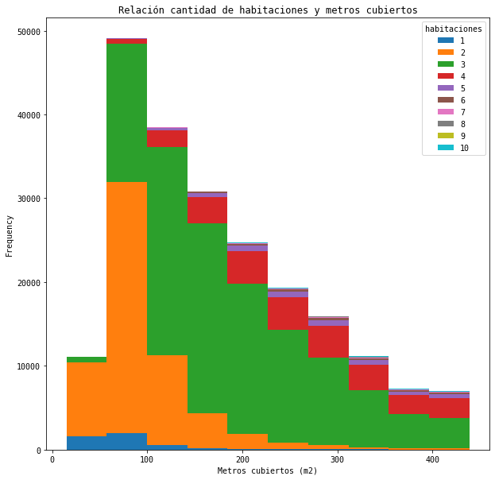

```python
convert_dict={'habitaciones':'int'}
publicaciones_viviendas_con_habitaciones = publicaciones_viviendas.loc[~publicaciones_viviendas['habitaciones'].isnull(), ['habitaciones','metroscubiertos']].astype(convert_dict)
ax = publicaciones_viviendas_con_habitaciones.pivot(columns='habitaciones')['metroscubiertos'].plot(kind = 'hist', stacked=True, figsize=(10,10), title="Relación cantidad de habitaciones y metros cubiertos")
ax.set_xlabel("Metros cubiertos (m2)")
```

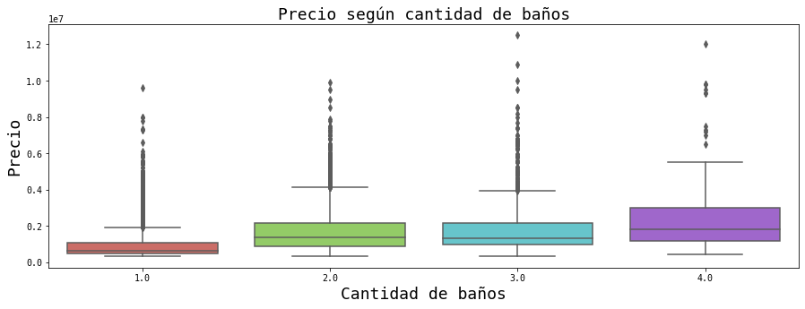

```python
precio_viviendas_con_bano_90_a_100 = publicaciones_viviendas.loc[(~publicaciones_viviendas['banos'].isnull()) & (publicaciones_viviendas['metrostotales'] >= 90) & (publicaciones_viviendas['metrostotales'] <= 100)]
get_boxplot(precio_viviendas_con_bano_90_a_100, 'banos', 'precio', (15,5), title="Precio según cantidad de baños", label_x="Cantidad de baños", label_y="Precio")
```

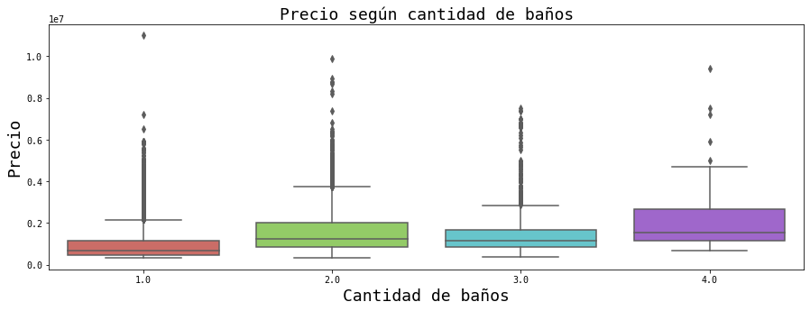

```python
precio_viviendas_con_bano_80_a_90 = publicaciones_viviendas.loc[(~publicaciones_viviendas['banos'].isnull()) & (publicaciones_viviendas['metrostotales'] >= 80) & (publicaciones_viviendas['metrostotales'] <= 90)]
get_boxplot(precio_viviendas_con_bano_80_a_90, 'banos', 'precio', (15,5), title="Precio según cantidad de baños", label_x="Cantidad de baños", label_y="Precio")
```

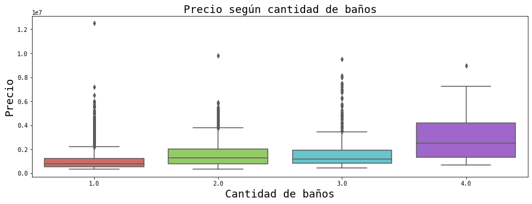

```python
precio_viviendas_con_bano_70_a_80 = publicaciones_viviendas.loc[(~publicaciones_viviendas['banos'].isnull()) & (publicaciones_viviendas['metrostotales'] >= 70) & (publicaciones_viviendas['metrostotales'] <= 80)]
get_boxplot(precio_viviendas_con_bano_70_a_80, 'banos', 'precio', (15,5), title="Precio según cantidad de baños", label_x="Cantidad de baños", label_y="Precio")
```

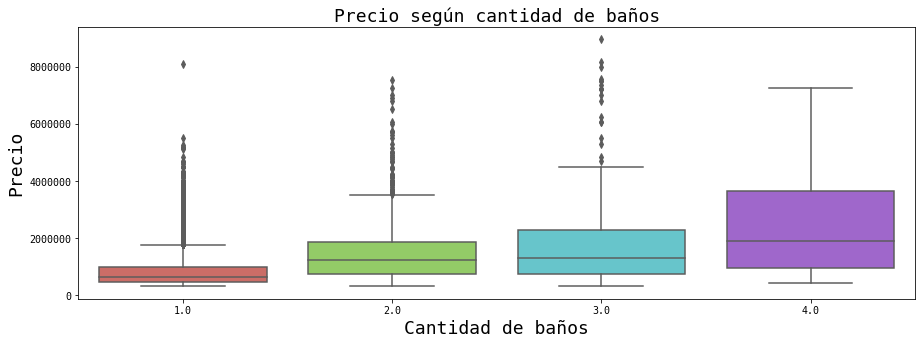

```python
precio_viviendas_con_bano_60_a_70 = publicaciones_viviendas.loc[(~publicaciones_viviendas['banos'].isnull()) & (publicaciones_viviendas['metrostotales'] >= 60) & (publicaciones_viviendas['metrostotales'] <= 70)]
get_boxplot(precio_viviendas_con_bano_60_a_70, 'banos', 'precio', (15,5), title="Precio según cantidad de baños", label_x="Cantidad de baños", label_y="Precio")
```

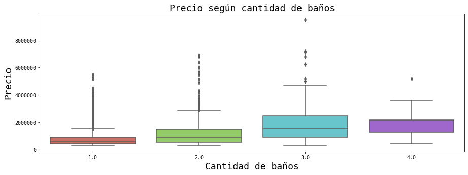

```python
precio_viviendas_con_bano_50_a_60 = publicaciones_viviendas.loc[(~publicaciones_viviendas['banos'].isnull()) & (publicaciones_viviendas['metrostotales'] >= 50) & (publicaciones_viviendas['metrostotales'] <= 60)]
get_boxplot(precio_viviendas_con_bano_50_a_60, 'banos', 'precio', (15,5), title="Precio según cantidad de baños", label_x="Cantidad de baños", label_y="Precio")
```

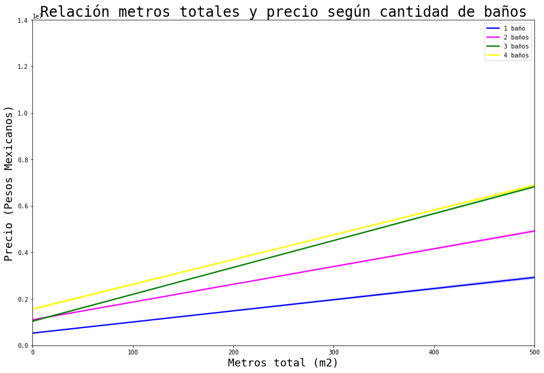

```python
publicaciones_1_bano = publicaciones_viviendas.loc[(~publicaciones_viviendas['banos'].isnull()) & (publicaciones_viviendas['banos'] == 1)]
publicaciones_2_bano = publicaciones_viviendas.loc[(~publicaciones_viviendas['banos'].isnull()) & (publicaciones_viviendas['banos'] == 2)]
publicaciones_3_bano = publicaciones_viviendas.loc[(~publicaciones_viviendas['banos'].isnull()) & (publicaciones_viviendas['banos'] == 3)]
publicaciones_4_bano = publicaciones_viviendas.loc[(~publicaciones_viviendas['banos'].isnull()) & (publicaciones_viviendas['banos'] == 4)]
f, ax = plt.subplots(figsize=(15,10))
ax.set(xlim=(0, 500), ylim=(0, 14000000))
#sns.scatterplot(x='metrostotales', y='precio', data=publicaciones_viviendas.loc[publicaciones_viviendas['tipodepropiedad'] == 'Apartamento'])
sns.regplot(x=publicaciones_1_bano['metrostotales'],y=publicaciones_1_bano['precio'],color='blue',scatter=False)
sns.regplot(x=publicaciones_2_bano['metrostotales'],y=publicaciones_2_bano['precio'],color='magenta',scatter=False)
sns.regplot(x=publicaciones_3_bano['metrostotales'],y=publicaciones_3_bano['precio'],color='green',scatter=False)
sns.regplot(x=publicaciones_4_bano['metrostotales'],y=publicaciones_4_bano['precio'],color='yellow',scatter=False)

plt.legend(labels=['1 baño','2 baños','3 baños', '4 baños'])
plt.title('Relación metros totales y precio según cantidad de baños', size=24)
plt.xlabel('Metros total (m2)', size=18)
plt.ylabel('Precio (Pesos Mexicanos)', size=18);
```

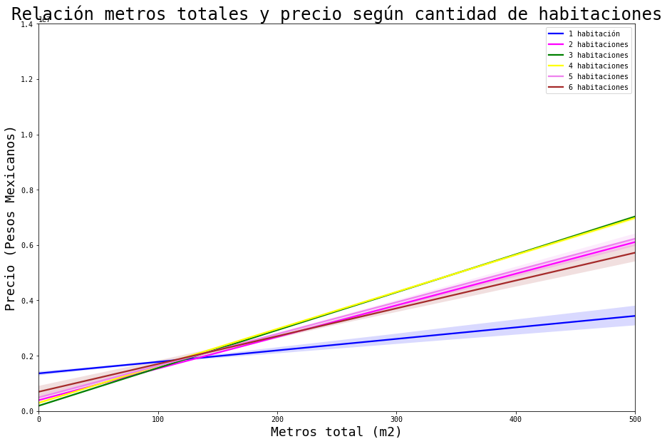

```python
publicaciones_1_habitacion = publicaciones_viviendas.loc[(~publicaciones_viviendas['habitaciones'].isnull()) & (publicaciones_viviendas['habitaciones'] == 1)]
publicaciones_2_habitacion = publicaciones_viviendas.loc[(~publicaciones_viviendas['habitaciones'].isnull()) & (publicaciones_viviendas['habitaciones'] == 2)]
publicaciones_3_habitacion = publicaciones_viviendas.loc[(~publicaciones_viviendas['habitaciones'].isnull()) & (publicaciones_viviendas['habitaciones'] == 3)]
publicaciones_4_habitacion = publicaciones_viviendas.loc[(~publicaciones_viviendas['habitaciones'].isnull()) & (publicaciones_viviendas['habitaciones'] == 4)]
publicaciones_5_habitacion = publicaciones_viviendas.loc[(~publicaciones_viviendas['habitaciones'].isnull()) & (publicaciones_viviendas['habitaciones'] == 5)]
publicaciones_6_habitacion = publicaciones_viviendas.loc[(~publicaciones_viviendas['habitaciones'].isnull()) & (publicaciones_viviendas['habitaciones'] == 6)]

f, ax = plt.subplots(figsize=(15,10))
ax.set(xlim=(0, 500), ylim=(0, 14000000))
#sns.scatterplot(x='metrostotales', y='precio', data=publicaciones_viviendas.loc[publicaciones_viviendas['tipodepropiedad'] == 'Apartamento'])
sns.regplot(x=publicaciones_1_habitacion['metrostotales'],y=publicaciones_1_habitacion['precio'],color='blue',scatter=False)
sns.regplot(x=publicaciones_2_habitacion['metrostotales'],y=publicaciones_2_habitacion['precio'],color='magenta',scatter=False)
sns.regplot(x=publicaciones_3_habitacion['metrostotales'],y=publicaciones_3_habitacion['precio'],color='green',scatter=False)
sns.regplot(x=publicaciones_4_habitacion['metrostotales'],y=publicaciones_4_habitacion['precio'],color='yellow',scatter=False)
sns.regplot(x=publicaciones_5_habitacion['metrostotales'],y=publicaciones_5_habitacion['precio'],color='violet',scatter=False)
sns.regplot(x=publicaciones_6_habitacion['metrostotales'],y=publicaciones_6_habitacion['precio'],color='brown',scatter=False)

plt.legend(labels=['1 habitación','2 habitaciones','3 habitaciones', '4 habitaciones', '5 habitaciones', '6 habitaciones'])
plt.title('Relación metros totales y precio según cantidad de habitaciones', size=24)
plt.xlabel('Metros total (m2)', size=18)
plt.ylabel('Precio (Pesos Mexicanos)', size=18);
```